# Assignment 4

akankshamr@iisc.ac.in MG 222: Assignment IV Due Date: June 18, 2020

The text file in http://www.mgmt.iisc.ac.in/CM/MG222/Data Files/gdp.data contains time series of Quarterly GDP of India from 1996-97:Q1, to 2013-14:Q2, in 2004-05 prices, split across eight sectors (provided by RBI, and as agreed upon by various other government bodies such as CSO, NSSO, Finance Ministry etc.) as well as the net GDP, in its last nine columns. The column names are self-explanatory and are thus not repeated here. In this class, there are five groups for Assignments purpose. Each one of these groups must choose only one of the following columns for this assignment (analysis of any other column of data will not be accepted), and no two groups must analyse the same time series. The acceptable

columns (as they appear in gdp.data) are as follows.

Agriculture • Manufacturing • Trade, Hotels, Transport & Communication • Community, Social & Personal Services • Gross Domestic Product

```
                                      Community, Social & Personal Services
```

First leave aside the last four observations of 2012-13:Q3, 2012-13:Q4, 2013-14:Q1 and 2013-14:Q2, while you build the model. These will be used for checking out the quality of the forecasts based on the models you are about to build, and thus must not be used for modelbuilding purpose. That is, your models must be built based on the 66 observations from 1996-97:Q1 to 2012-13:Q2. Answer the following.

1. Build a regression model that you deem to be most appropriate for modeling the trend and seasonality present in your chosen time series. Do the residulas of this regression model satisfy all the required assumptions? [7+3=10]

```r
library("zoo")
library(dplyr)
library(car)
library(corrplot)
library(MASS)
library(lmtest)
library("tseries")
library("forecast")
```

66 observations from 1996-97:Q1 to 2012-13:Q2

Year Quarter Agriculture Mining Manufacturing Electricity,Gas&WaterSupply Construction Trade,Hotels,Transport&Communication Finance,Insurance,RealEstate&BusinessServices Community,Social&PersonalServices GrossDomesticProduct

```r
data <- read.table("C:/Users/Akanksha/Documents/R Files/MG222/assignment4data.csv", header = T)  ## Read
data
```

| Year | Quarter | Agriculture | Mining | Manufacturing | Electricity.Gas.WaterSupply | Construction | Trade.Hotels.Transport.Communication | Finance.Insurance.RealEstate.BusinessServices | Community.Social.PersonalServices | GrossDomesticProduct |
| --- | --- | --- | --- | --- | --- | --- | --- | --- | --- | --- |
| 1996-97 | Q1 | 828.06 | 65.41 | 545.33 | 85.16 | 145.29 | 638.10 | 399.96 | 352.41 | 3059.27 |
| 1996-97 | Q2 | 643.34 | 68.25 | 546.14 | 84.56 | 151.02 | 634.78 | 414.81 | 359.16 | 2901.54 |
| 1996-97 | Q3 | 1209.87 | 75.67 | 563.35 | 88.42 | 155.18 | 743.01 | 421.99 | 377.75 | 3633.96 |
| 1996-97 | Q4 | 970.89 | 83.73 | 607.83 | 90.50 | 171.77 | 766.06 | 445.87 | 559.93 | 3703.81 |
| 1997-98 | Q1 | 911.98 | 87.76 | 561.37 | 99.23 | 180.98 | 737.64 | 459.33 | 383.06 | 3418.45 |
| 1997-98 | Q2 | 702.57 | 77.60 | 569.49 | 101.36 | 181.42 | 722.55 | 462.88 | 404.89 | 3221.28 |
| 1997-98 | Q3 | 1253.18 | 89.55 | 594.62 | 101.51 | 198.46 | 851.25 | 478.30 | 433.35 | 3998.60 |
| 1997-98 | Q4 | 1007.83 | 98.60 | 627.73 | 107.81 | 213.26 | 877.78 | 515.54 | 692.68 | 4149.94 |
| 1998-99 | Q1 | 1000.80 | 78.94 | 610.89 | 127.10 | 218.68 | 839.14 | 525.90 | 486.89 | 3885.84 |
| 1998-99 | Q2 | 800.33 | 86.95 | 623.62 | 121.28 | 216.96 | 843.72 | 539.87 | 563.53 | 3797.32 |

[output cut: 60 more lines]

```r
ts1<-ts(data$Community.Social.PersonalServices)
ts2<-ts1[1:66]
tsc=ts(ts2,deltat = 1/4)
tt=1:70
t=tt[1:66]

plot(t,tsc,type="n",main="Quarterly GDP of India from 1996-97 to 2012-13",xlab="Time",ylab="Quarterly GDP in Crores of Rs")
lines(t,tsc)
```

```r
points(t,tsc,pch=20)
legend("topleft", c(" Community,Social&PersonalServices(Observed)","Trend"), lty=c(1,1), col=c('black','blue'), bty='n', cex=1)
```

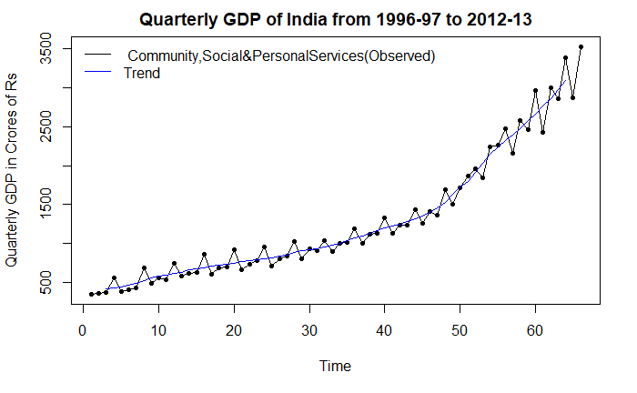

```r
decomposed.tsc<-decompose(tsc)
lines(t,decomposed.tsc$trend,col='blue',lwd=1.25)
```

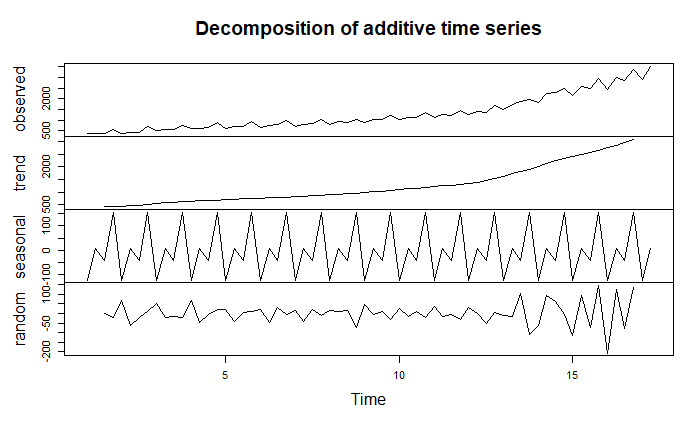

```r
plot(decomposed.tsc)
```

```r
tsc
```

```
      Qtr1    Qtr2    Qtr3    Qtr4
1   352.41  359.16  377.75  559.93
2   383.06  404.89  433.35  692.68
3   486.89  563.53  538.75  750.17
4   578.47  619.59  631.20  867.59
5   603.23  688.03  701.67  916.07
6   663.47  737.89  781.30  956.88
7   713.06  798.82  838.21 1029.51
8   805.05  933.03  905.53 1034.82
9   903.83 1008.39 1010.04 1191.35
10 1003.95 1121.76 1135.54 1330.25
11 1137.15 1241.49 1234.74 1437.82
12 1265.18 1409.96 1371.08 1691.68
13 1502.06 1714.81 1864.29 1957.79
14 1842.51 2243.06 2267.46 2477.31
15 2155.62 2577.38 2464.49 2963.63
16 2434.60 2996.09 2855.76 3388.74
17 2878.26 3530.86
```

1. Build a regression model that you deem to be most appropriate for modeling the trend and seasonality present in your chosen time series. Do the residulas of this regression model satisfy all the required assumptions?

Model 1. First Regression Model, which is simple linear function of t

```r
model1<-lm(tsc~t)
summary(model1)
```

```
Call:
lm(formula = tsc ~ t)

Residuals:
    Min      1Q  Median      3Q     Max
-478.38 -240.93  -44.98  191.85  963.91

Coefficients:
            Estimate Std. Error t value Pr(>|t|)
(Intercept)  -20.859     81.539  -0.256    0.799
t             39.209      2.116  18.532   <2e-16 ***
---
Signif. codes:  0 ‘***’ 0.001 ‘**’ 0.01 ‘*’ 0.05 ‘.’ 0.1 ‘ ’ 1

Residual standard error: 327.5 on 64 degrees of freedom
Multiple R-squared:  0.8429,    Adjusted R-squared:  0.8405
F-statistic: 343.4 on 1 and 64 DF,  p-value: < 2.2e-16
```

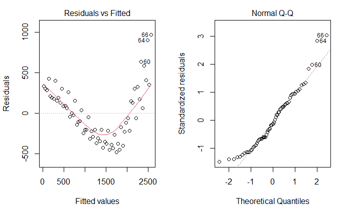

```r
par(mfrow = c(1, 2))
plot(model1,which=1:2)
```

```r
res1<-residuals(model1)/sqrt(327.5)
boxplot(res1)

plot(t,res1)
```

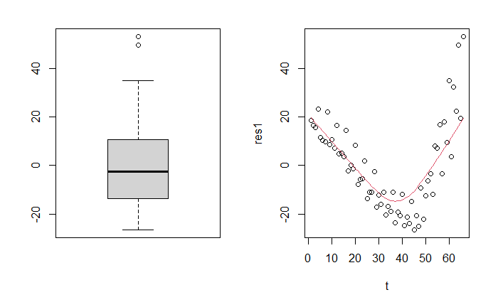

```r
lines(lowess(t,res1),col=2)
```

```r
library(nortest)
ad.test(sres1)
```

```
    Anderson-Darling normality test

data:  sres1
A = 1.0153, p-value = 0.01055
```

```r
cvm.test(sres1)
```

```
    Cramer-von Mises normality test

data:  sres1
W = 0.14266, p-value = 0.02885
```

```r
lillie.test(sres1)
```

```
    Lilliefors (Kolmogorov-Smirnov) normality test

data:  sres1
D = 0.10762, p-value = 0.05562
```

```r
pearson.test(sres1)
```

```
    Pearson chi-square normality test

data:  sres1
P = 28, p-value = 0.0004742
```

```r
sf.test(sres1)
```

```
    Shapiro-Francia normality test

data:  sres1
W = 0.94395, p-value = 0.006472
```

```r
normtest(res1)
```

| Method | P.Value |
| --- | --- |
| Shapiro-Wilk normality test | 0.00844284 |
| Anderson-Darling normality test | 0.05472559 |
| Cramer-von Mises normality test | 0.12630193 |
| Lilliefors (Kolmogorov-Smirnov) normality test | 0.05111634 |
| Shapiro-Francia normality test | 0.01303466 |

Model 2: Second Regression Model, which is a quadratic function of t and a linear t

```r
t1=t*t
model2<-lm(tsc~t+t1)
summary(model2)
```

```
Call:
lm(formula = tsc ~ t + t1)

Residuals:
   Min     1Q Median     3Q    Max
-298.5 -136.9    0.5  100.8  421.6

Coefficients:
             Estimate Std. Error t value Pr(>|t|)
(Intercept) 619.75337   66.40529   9.333 1.73e-13 ***
t           -17.31538    4.57360  -3.786 0.000344 ***
t1            0.84365    0.06616  12.752  < 2e-16 ***
---
Signif. codes:  0 ‘***’ 0.001 ‘**’ 0.01 ‘*’ 0.05 ‘.’ 0.1 ‘ ’ 1

Residual standard error: 174.4 on 63 degrees of freedom
Multiple R-squared:  0.9561,    Adjusted R-squared:  0.9547
F-statistic: 686.6 on 2 and 63 DF,  p-value: < 2.2e-16
```

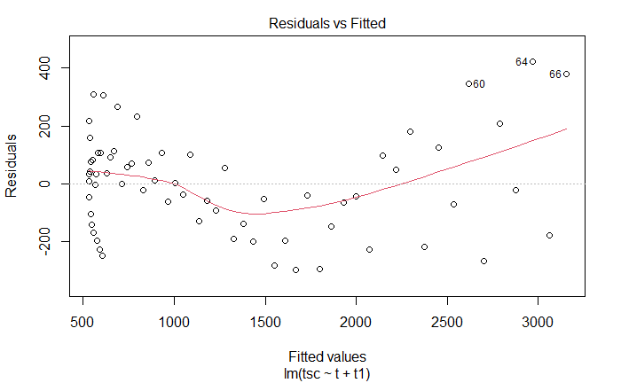

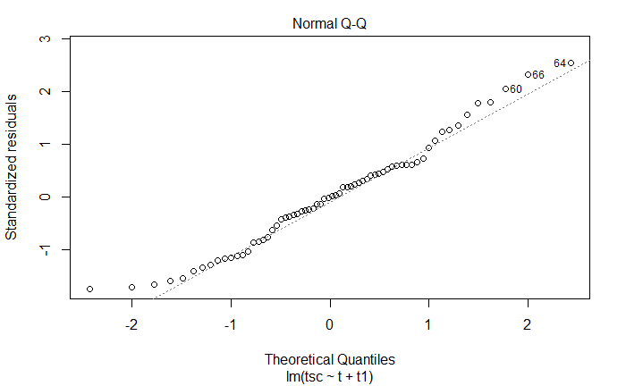

```r
plot(model2,which=1:2)
```

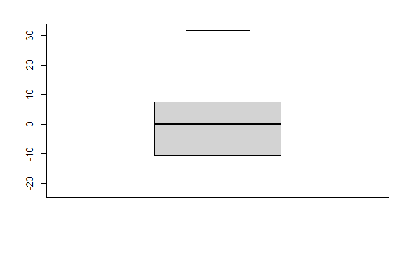

```r
sres2<-residuals(model2)/sqrt(174.4)
boxplot(sres2)
```

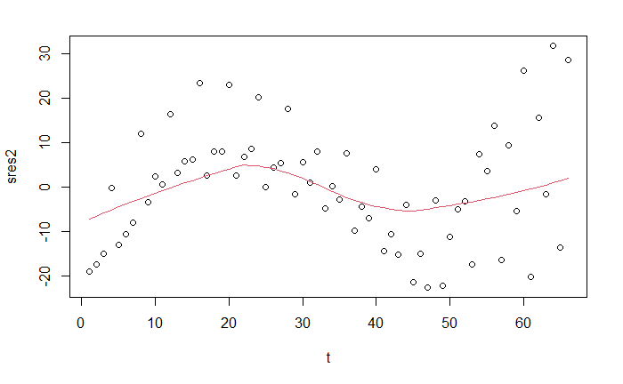

```r
plot(t,sres2)
lines(lowess(t,sres2),col=2)
```

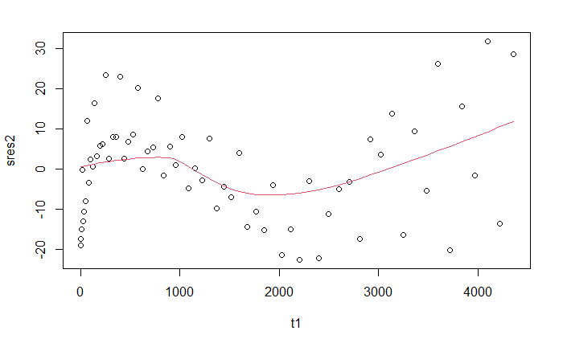

```r
plot(t1,sres2)
lines(lowess(t1,sres2),col=2)
```

```r
library(nortest)
ad.test(sres2)
```

```
    Anderson-Darling normality test

data:  sres2
A = 0.33348, p-value = 0.5043
```

```r
cvm.test(sres2)
```

```
    Cramer-von Mises normality test

data:  sres2
W = 0.03975, p-value = 0.681
```

```r
lillie.test(sres2)
```

```
    Lilliefors (Kolmogorov-Smirnov) normality test

data:  sres2
D = 0.07246, p-value = 0.5294
```

```r
pearson.test(sres2)
```

```
    Pearson chi-square normality test

data:  sres2
P = 3.3333, p-value = 0.9117
```

```r
sf.test(sres2)
```

```
    Shapiro-Francia normality test

data:  sres2
W = 0.98201, p-value = 0.3828
```

```r
normtest(sres2)
```

| Method | P.Value |
| --- | --- |
| Shapiro-Wilk normality test | 0.2639254 |
| Anderson-Darling normality test | 0.5043019 |
| Cramer-von Mises normality test | 0.6810200 |
| Lilliefors (Kolmogorov-Smirnov) normality test | 0.5293511 |
| Shapiro-Francia normality test | 0.3827683 |

Model 3: Third Regression model,

```r
model3=lm(log(tsc)~t)
summary(model3)
```

```
Call:
lm(formula = log(tsc) ~ t)

Residuals:
     Min       1Q   Median       3Q      Max
-0.19447 -0.10107 -0.02290  0.05859  0.35530

Coefficients:
             Estimate Std. Error t value Pr(>|t|)
(Intercept) 5.9361494  0.0332922  178.31   <2e-16 ***
t           0.0311399  0.0008639   36.05   <2e-16 ***
---
Signif. codes:  0 ‘***’ 0.001 ‘**’ 0.01 ‘*’ 0.05 ‘.’ 0.1 ‘ ’ 1

Residual standard error: 0.1337 on 64 degrees of freedom
Multiple R-squared:  0.9531,    Adjusted R-squared:  0.9523
F-statistic:  1299 on 1 and 64 DF,  p-value: < 2.2e-16
```

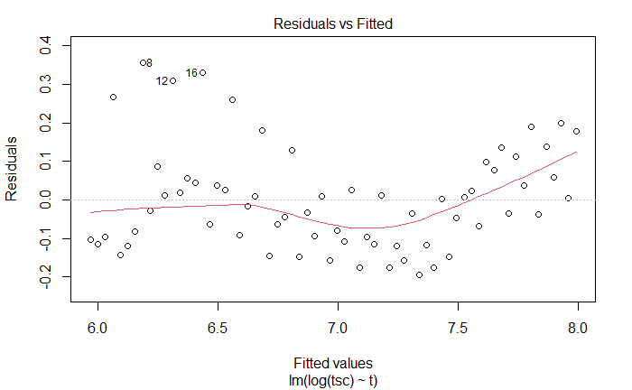

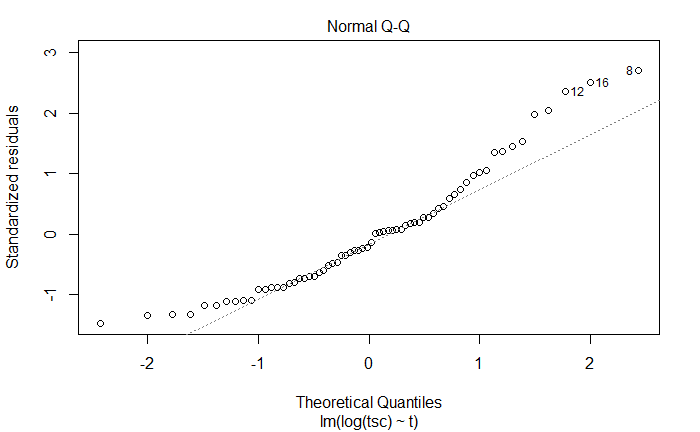

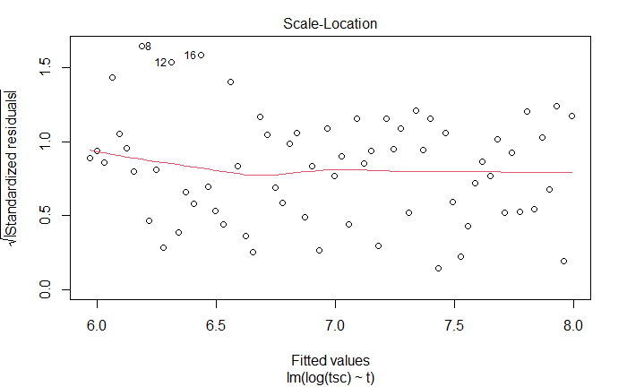

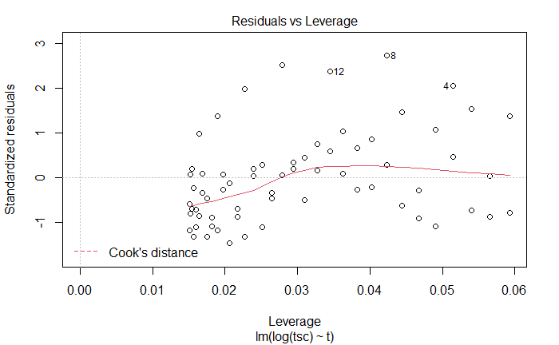

```r
plot(model3)
```

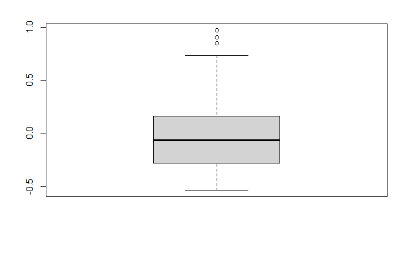

```r
sres3<-residuals(model3)/sqrt(0.1337)
boxplot(sres3)
```

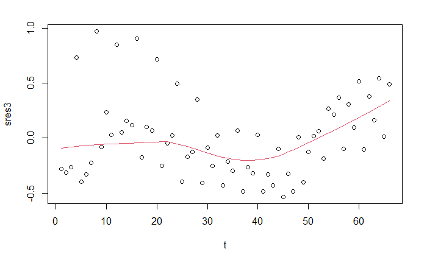

```r
plot(t,sres3)
lines(lowess(t,sres3),col=2)
```

```r
library(nortest)
ad.test(sres2)
```

```
    Anderson-Darling normality test

data:  sres2
A = 0.33348, p-value = 0.5043
```

```r
cvm.test(sres2)
```

```
    Cramer-von Mises normality test

data:  sres2
W = 0.03975, p-value = 0.681
```

```r
lillie.test(sres2)
```

```
    Lilliefors (Kolmogorov-Smirnov) normality test

data:  sres2
D = 0.07246, p-value = 0.5294
```

```r
pearson.test(sres2)
```

```
    Pearson chi-square normality test

data:  sres2
P = 3.3333, p-value = 0.9117
```

```r
sf.test(sres2)
```

```
    Shapiro-Francia normality test

data:  sres2
W = 0.98201, p-value = 0.3828
```

```r
model3=lm(log(tsc)~t+t1)
summary(model3)
```

```
Call:
lm(formula = log(tsc) ~ t + t1)

Residuals:
     Min       1Q   Median       3Q      Max
-0.20332 -0.08771 -0.00566  0.06046  0.33886

Coefficients:
             Estimate Std. Error t value Pr(>|t|)
(Intercept) 6.0369797  0.0484835 124.516  < 2e-16 ***
t           0.0222431  0.0033393   6.661 7.76e-09 ***
t1          0.0001328  0.0000483   2.749  0.00779 **
---
Signif. codes:  0 ‘***’ 0.001 ‘**’ 0.01 ‘*’ 0.05 ‘.’ 0.1 ‘ ’ 1

Residual standard error: 0.1273 on 63 degrees of freedom
Multiple R-squared:  0.9581,    Adjusted R-squared:  0.9568
F-statistic:   720 on 2 and 63 DF,  p-value: < 2.2e-16
```

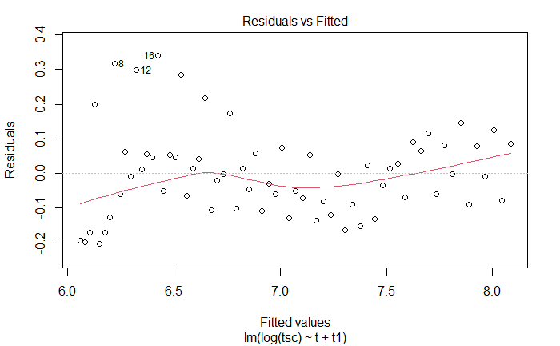

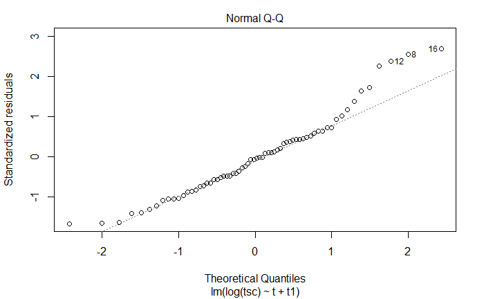

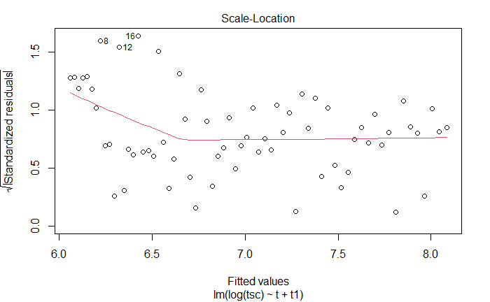

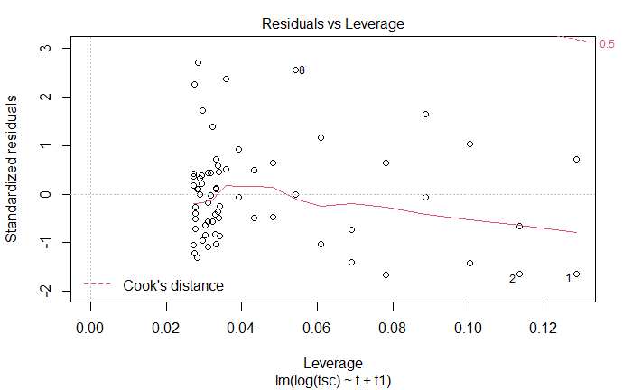

```r
plot(model3)
```

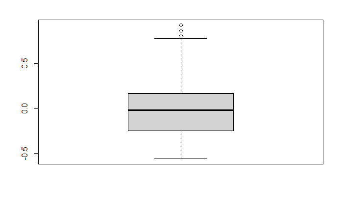

```r
sres3<-residuals(model3)/sqrt(0.1337)
boxplot(sres3)
```

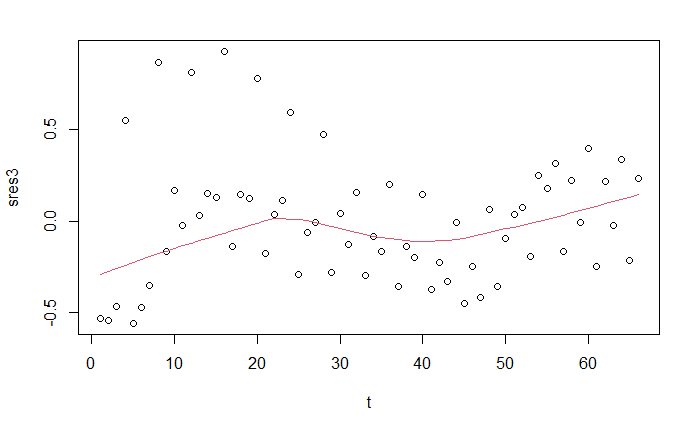

```r
plot(t,sres3)
lines(lowess(t,sres3),col=2)
```

```r
library(nortest)
ad.test(sres2)
```

```
    Anderson-Darling normality test

data:  sres2
A = 0.6707, p-value = 0.07636
```

```r
cvm.test(sres2)
```

```
    Cramer-von Mises normality test

data:  sres2
W = 0.11855, p-value = 0.06105
```

```r
lillie.test(sres2)
```

```
    Lilliefors (Kolmogorov-Smirnov) normality test

data:  sres2
D = 0.11016, p-value = 0.04537
```

```r
pearson.test(sres2)
```

```
    Pearson chi-square normality test

data:  sres2
P = 12, p-value = 0.1512
```

```r
sf.test(sres2)
```

```
    Shapiro-Francia normality test

data:  sres2
W = 0.97574, p-value = 0.1911
```

```r
normtest(sres2)
```

| Method | P.Value |
| --- | --- |
| Shapiro-Wilk normality test | 0.10680164 |
| Anderson-Darling normality test | 0.07636415 |
| Cramer-von Mises normality test | 0.06105460 |
| Lilliefors (Kolmogorov-Smirnov) normality test | 0.04536515 |
| Shapiro-Francia normality test | 0.19110042 |

Model 4:

```r
w1=pi;
t1=t*t
model4=lm(tsc~t+t1+cos(w1*t)+sin(w1*0.5*t)+t1*sin(w1*0.5*t)+t1*cos(w1*0.5*t))
summary(model4)
```

```
Call:
lm(formula = tsc ~ t + t1 + cos(w1 * t) + sin(w1 * 0.5 * t) +
    t1 * sin(w1 * 0.5 * t) + t1 * cos(w1 * 0.5 * t))

Residuals:
    Min      1Q  Median      3Q     Max
-270.77  -86.52    9.67   94.99  321.30

Coefficients:
                      Estimate Std. Error t value Pr(>|t|)
(Intercept)          634.54955   53.00993  11.970  < 2e-16 ***
t                    -18.21255    3.65164  -4.987 5.88e-06 ***
t1                     0.85509    0.05286  16.177  < 2e-16 ***
cos(w1 * t)           87.53126   17.11706   5.114 3.72e-06 ***
sin(w1 * 0.5 * t)    -14.75674   36.32770  -0.406  0.68608
cos(w1 * 0.5 * t)    106.67300   36.67509   2.909  0.00514 **
t1:sin(w1 * 0.5 * t)  -0.02135    0.01868  -1.143  0.25761
t1:cos(w1 * 0.5 * t)  -0.02397    0.01816  -1.319  0.19220
---
Signif. codes:  0 ‘***’ 0.001 ‘**’ 0.01 ‘*’ 0.05 ‘.’ 0.1 ‘ ’ 1

Residual standard error: 138.9 on 58 degrees of freedom
Multiple R-squared:  0.9744,    Adjusted R-squared:  0.9713
F-statistic: 315.1 on 7 and 58 DF,  p-value: < 2.2e-16
```

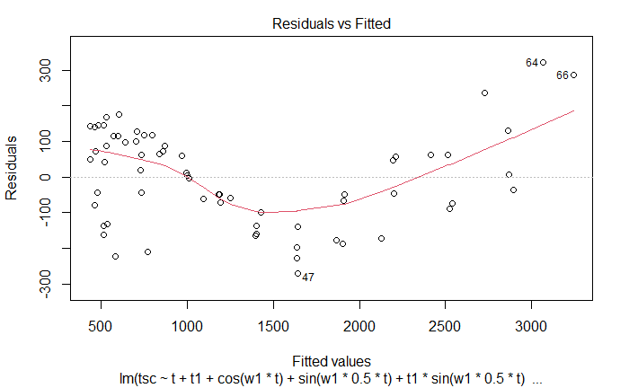

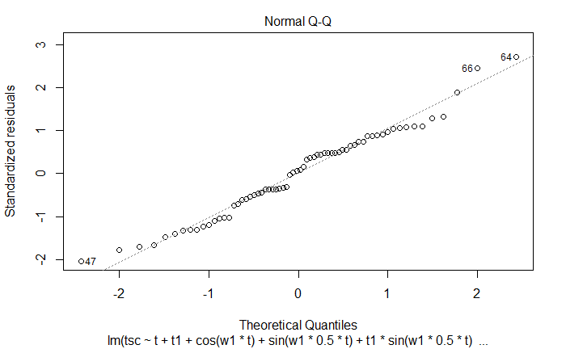

```r
plot(model4,which=1:2)
```

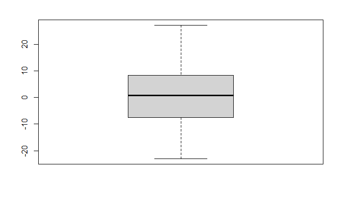

```r
sres4=residuals(model4)/sqrt(138.9)
boxplot(sres4)
```

```r
library(nortest)
ad.test(sres4)
```

```
    Anderson-Darling normality test

data:  sres4
A = 0.52007, p-value = 0.1797
```

```r
cvm.test(sres4)
```

```
    Cramer-von Mises normality test

data:  sres4
W = 0.089542, p-value = 0.1529
```

```r
lillie.test(sres4)
```

```
    Lilliefors (Kolmogorov-Smirnov) normality test

data:  sres4
D = 0.096719, p-value = 0.1311
```

```r
pearson.test(sres4)
```

```
    Pearson chi-square normality test

data:  sres4
P = 18, p-value = 0.02123
```

```r
sf.test(sres4)
```

```
    Shapiro-Francia normality test

data:  sres4
W = 0.98201, p-value = 0.3826
```

```r
library(tseries)
res4=residuals(model4)
Box.test(res4)
```

```
    Box-Pierce test

data:  res4
X-squared = 19.928, df = 1, p-value = 8.042e-06
```

```r
res4=residuals(model4)
turning_point.test<-function(x)
{
     n<-length(x)
    turns<-0
    for(i in 2:(n-1))
    if((x[i-1]<x[i] && x[i]>x[i+1]) || (x[i-1]>x[i] && x[i]<x[i+1]))
    turns<-turns+1
    z<-(turns-2*(n-2)/3)/sqrt((16*n-29)/90)
    return(list(nturns=turns,z=z,p=2*(1-pnorm(abs(z)))))
     }
turning_point.test(res4)
```

```
$nturns
[1] 53

$z
[1] 3.058979

$p
[1] 0.002220928
```

```r
diff_sign.test<-function(x)
{
n<-length(x)
y<-diff(x)
t<-length(y[y>0])
z<-(t-(n-1)/2)/sqrt((n+1)/12)
return(list(t=t,z=z,p=2*(1-pnorm(abs(z)))))
}
diff_sign.test(res4)
```

```
$t
[1] 33

$z
[1] 0.2116037

$p
[1] 0.8324162
```

```r
linear_trend.test<-function(x)
{
n<-length(x)
t<-0
for(i in 1:(n-1))
for(j in (i+1):n)
if(x[j]>x[i]) t<-t+1
z<-(t-n*(n-1)/4)/sqrt((n*(n-1)*(2*n+5)/72))
return(list(t=t,z=z,p=2*(1-pnorm(abs(z)))))
}
linear_trend.test(res4)
```

```
$t
[1] 995

$z
[1] -0.8577861

$p
[1] 0.3910106
```

Model 5:

```r
w1=pi;
t1=t*t
model5=lm(tsc~t+t1+cos(w1*t)+cos(w1*0.5*t))
summary(model5)
```

```
Call:
lm(formula = tsc ~ t + t1 + cos(w1 * t) + cos(w1 * 0.5 * t))

Residuals:
    Min      1Q  Median      3Q     Max
-257.33 -115.77   23.34   99.14  358.25

Coefficients:
                   Estimate Std. Error t value Pr(>|t|)
(Intercept)       630.42644   54.50552  11.566  < 2e-16 ***
t                 -17.92708    3.75423  -4.775 1.17e-05 ***
t1                  0.85098    0.05431  15.669  < 2e-16 ***
cos(w1 * t)        88.71642   17.61245   5.037 4.48e-06 ***
cos(w1 * 0.5 * t)  70.20296   24.93353   2.816  0.00655 **
---
Signif. codes:  0 ‘***’ 0.001 ‘**’ 0.01 ‘*’ 0.05 ‘.’ 0.1 ‘ ’ 1

Residual standard error: 143 on 61 degrees of freedom
Multiple R-squared:  0.9714,    Adjusted R-squared:  0.9696
F-statistic: 518.8 on 4 and 61 DF,  p-value: < 2.2e-16
```

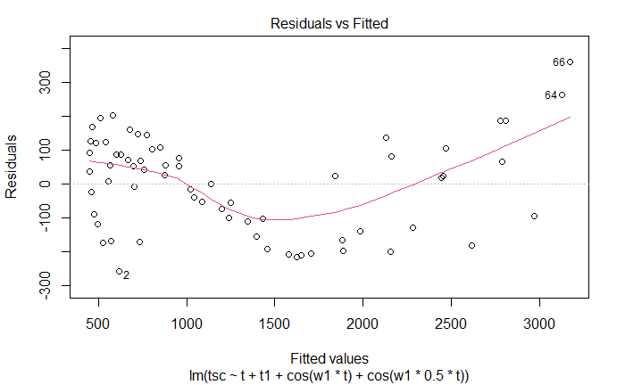

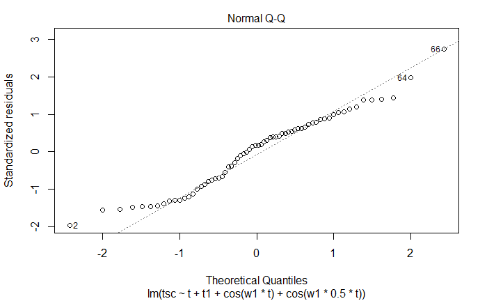

```r
model4<-model5
plot(model4,which=1:2)
```

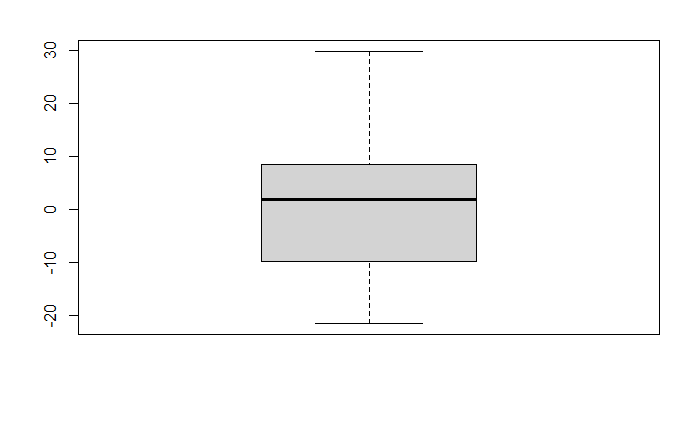

```r
sres4=residuals(model4)/sqrt(143)
boxplot(sres4)
```

```r
library(nortest)
ad.test(sres4)
```

```
    Anderson-Darling normality test

data:  sres4
A = 0.76312, p-value = 0.04489
```

```r
cvm.test(sres4)
```

```
    Cramer-von Mises normality test

data:  sres4
W = 0.12189, p-value = 0.05498
```

```r
lillie.test(sres4)
```

```
    Lilliefors (Kolmogorov-Smirnov) normality test

data:  sres4
D = 0.08926, p-value = 0.2148
```

```r
pearson.test(sres4)
```

```
    Pearson chi-square normality test

data:  sres4
P = 8.3333, p-value = 0.4016
```

```r
sf.test(sres4)
```

```
    Shapiro-Francia normality test

data:  sres4
W = 0.97058, p-value = 0.1065
```

```r
library(tseries)
res4=residuals(model4)
Box.test(res4)
```

```
    Box-Pierce test

data:  res4
X-squared = 14.385, df = 1, p-value = 0.000149
```

```r
res4=residuals(model4)
turning_point.test<-function(x)
{
     n<-length(x)
    turns<-0
    for(i in 2:(n-1))
    if((x[i-1]<x[i] && x[i]>x[i+1]) || (x[i-1]>x[i] && x[i]<x[i+1]))
    turns<-turns+1
    z<-(turns-2*(n-2)/3)/sqrt((16*n-29)/90)
    return(list(nturns=turns,z=z,p=2*(1-pnorm(abs(z)))))
     }
turning_point.test(res4)
```

```
$nturns
[1] 49

$z
[1] 1.874858

$p
[1] 0.06081226
```

```r
diff_sign.test<-function(x)
{
n<-length(x)
y<-diff(x)
t<-length(y[y>0])
z<-(t-(n-1)/2)/sqrt((n+1)/12)
return(list(t=t,z=z,p=2*(1-pnorm(abs(z)))))
}
diff_sign.test(res4)
```

```
$t
[1] 31

$z
[1] -0.6348111

$p
[1] 0.5255517
```

```r
linear_trend.test<-function(x)
{
n<-length(x)
t<-0
for(i in 1:(n-1))
for(j in (i+1):n)
if(x[j]>x[i]) t<-t+1
z<-(t-n*(n-1)/4)/sqrt((n*(n-1)*(2*n+5)/72))
return(list(t=t,z=z,p=2*(1-pnorm(abs(z)))))
}
linear_trend.test(res4)
```

```
$t
[1] 1018

$z
[1] -0.6032173

$p
[1] 0.5463641
```

```r
t=1:66
t1=t*t
w1=pi
reg_model=lm(tsc~t+t1+cos(w1*t)+cos(w1*0.5*t))
summary(reg_model)
```

```
Call:
lm(formula = tsc ~ t + t1 + cos(w1 * t) + cos(w1 * 0.5 * t))

Residuals:
    Min      1Q  Median      3Q     Max
-257.33 -115.77   23.34   99.14  358.25

Coefficients:
                   Estimate Std. Error t value Pr(>|t|)
(Intercept)       630.42644   54.50552  11.566  < 2e-16 ***
t                 -17.92708    3.75423  -4.775 1.17e-05 ***
t1                  0.85098    0.05431  15.669  < 2e-16 ***
cos(w1 * t)        88.71642   17.61245   5.037 4.48e-06 ***
cos(w1 * 0.5 * t)  70.20296   24.93353   2.816  0.00655 **
---
Signif. codes:  0 ‘***’ 0.001 ‘**’ 0.01 ‘*’ 0.05 ‘.’ 0.1 ‘ ’ 1

Residual standard error: 143 on 61 degrees of freedom
Multiple R-squared:  0.9714,    Adjusted R-squared:  0.9696
F-statistic: 518.8 on 4 and 61 DF,  p-value: < 2.2e-16
```

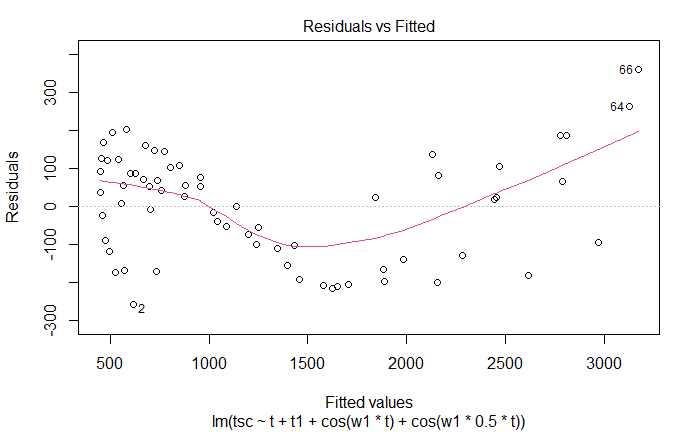

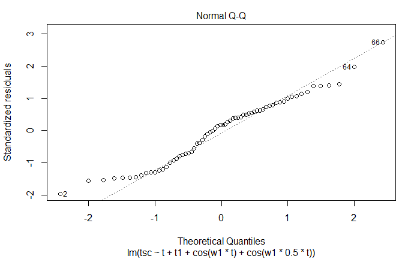

```r
plot(model4,which=1:2)
```

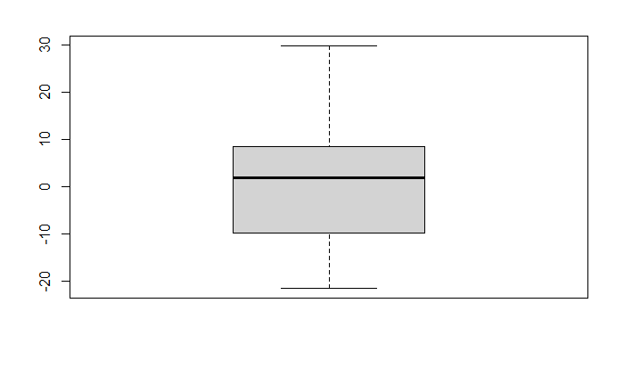

```r
res=residuals(reg_model)/sqrt(143)  # standard residual
boxplot(res)
```

```r
normtest<-function(x)
{
  library(nortest)
  s<-shapiro.test(x)
  ad<-ad.test(x)
  cvm<-cvm.test(x)
  ll<-lillie.test(x)
  sf<-sf.test(x)
  df<-data.frame(Method=c(s$method, ad$method, cvm$method, ll$method, sf$method),
                 P.Value=c(s$p.value, ad$p.value, cvm$p.value, ll$p.value, sf$p.value))
  df
}
normtest(res)
```

| Method | P.Value |
| --- | --- |
| Shapiro-Wilk normality test | 0.07866568 |
| Anderson-Darling normality test | 0.04488698 |
| Cramer-von Mises normality test | 0.05498091 |
| Lilliefors (Kolmogorov-Smirnov) normality test | 0.21476873 |
| Shapiro-Francia normality test | 0.10653092 |

```r
Box.test(res,lag=20)
```

```
    Box-Pierce test

data:  res
X-squared = 147.44, df = 20, p-value < 2.2e-16
```

```r
Box.test(res,type="L",lag=20)
```

```
    Box-Ljung test

data:  res
X-squared = 175.35, df = 20, p-value < 2.2e-16
```

```r
turning_point.test(res)
```

```
$nturns
[1] 49

$z
[1] 1.874858

$p
[1] 0.06081226
```

```r
diff_sign.test(res)
```

```
$t
[1] 31

$z
[1] -0.6348111

$p
[1] 0.5255517
```

```r
linear_trend.test(res)
```

```
$t
[1] 1018

$z
[1] -0.6032173

$p
[1] 0.5463641
```

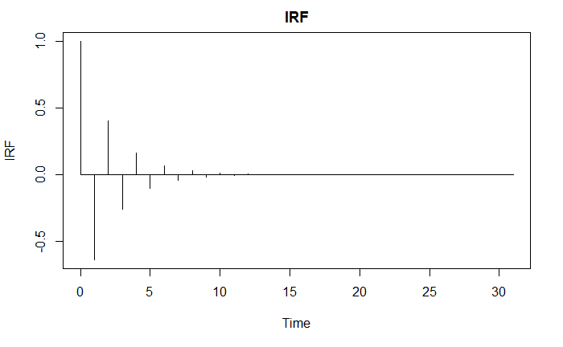

```r
irfplot(psi,"IRF")
```

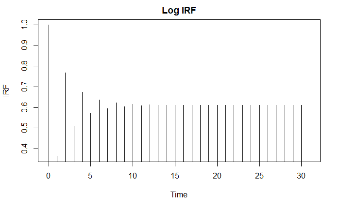

```r
irfplot(cumsum(psi)+1,"Log IRF")
```

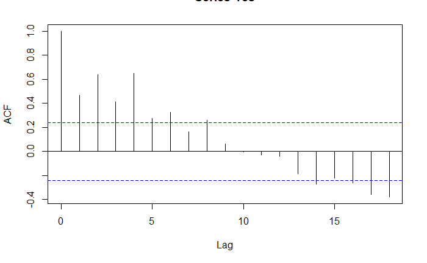

```r
acf(res)
```

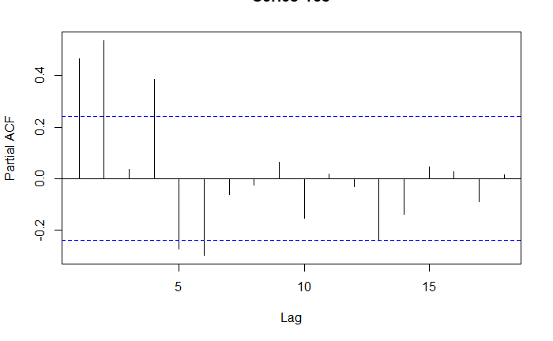

```r
pacf(res)
```

```r
#turning_point.test(res)
#diff_sign.test(res)
#linear_trend.test(res)
#Box.test(res,lag=20,type="L")
adf.test(diff(tsc,lag=4))$p.value
```

```
[1] 0.6779277
```

```r
pp.test(diff(tsc,lag=4))$p.value
```

```
p-value smaller than printed p-value
```

```
[1] 0.01
```

```r
kpss.test(diff(tsc,lag=4))$p.value
```

```
p-value smaller than printed p-value
```

```
[1] 0.01
```

Model 6:

```r
w1=pi;
t1=t*t
model5=lm((tsc)~t+t1+cos(w1*t)+t1:sin(w1*t))
summary(model5)
```

```
Call:
lm(formula = (tsc) ~ t + t1 + cos(w1 * t) + t1:sin(w1 * t))

Residuals:
    Min      1Q  Median      3Q     Max
-324.49  -89.93   14.48   90.09  311.53

Coefficients:
                 Estimate Std. Error t value Pr(>|t|)
(Intercept)     6.218e+02  5.506e+01  11.293  < 2e-16 ***
t              -1.727e+01  3.792e+00  -4.555 2.56e-05 ***
t1              8.409e-01  5.485e-02  15.330  < 2e-16 ***
cos(w1 * t)     6.454e+01  2.000e+01   3.228  0.00201 **
t1:sin(w1 * t) -2.348e+12  9.254e+11  -2.537  0.01374 *
---
Signif. codes:  0 ‘***’ 0.001 ‘**’ 0.01 ‘*’ 0.05 ‘.’ 0.1 ‘ ’ 1

Residual standard error: 144.6 on 61 degrees of freedom
Multiple R-squared:  0.9708,    Adjusted R-squared:  0.9689
F-statistic: 507.3 on 4 and 61 DF,  p-value: < 2.2e-16
```

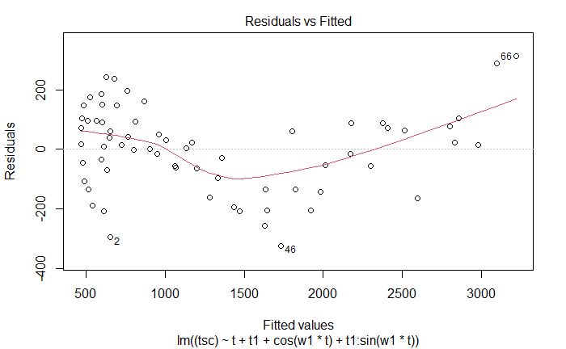

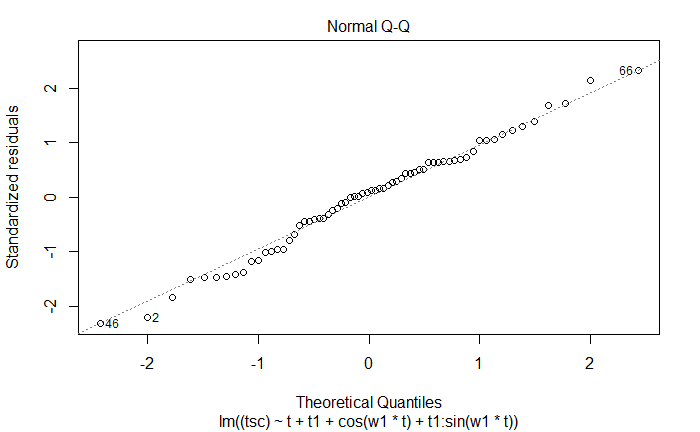

```r
model4<-model5
plot(model4,which=1:2)
```

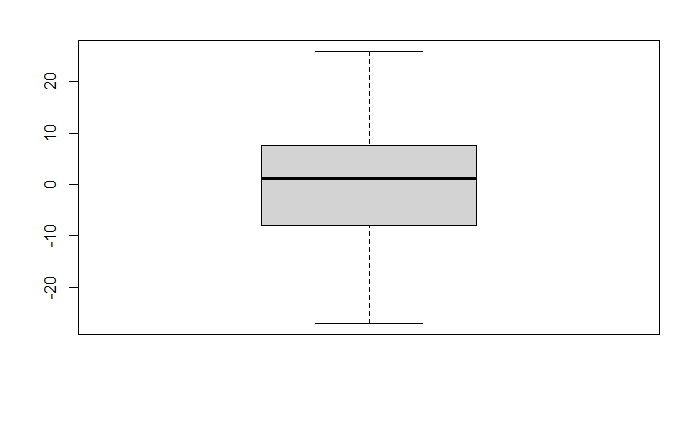

```r
sres4=residuals(model4)/sqrt(144.6)
boxplot(sres4)
```

```r
library(nortest)
ad.test(sres4)
```

```
    Anderson-Darling normality test

data:  sres4
A = 0.32073, p-value = 0.5238
```

```r
cvm.test(sres4)
```

```
    Cramer-von Mises normality test

data:  sres4
W = 0.056164, p-value = 0.4196
```

```r
lillie.test(sres4)
```

```
    Lilliefors (Kolmogorov-Smirnov) normality test

data:  sres4
D = 0.073935, p-value = 0.4964
```

```r
pearson.test(sres4)
```

```
    Pearson chi-square normality test

data:  sres4
P = 7.3333, p-value = 0.5011
```

```r
sf.test(sres4)
```

```
    Shapiro-Francia normality test

data:  sres4
W = 0.98998, p-value = 0.796
```

```r
library(tseries)
res4=residuals(model4)
Box.test(res4)
```

```
    Box-Pierce test

data:  res4
X-squared = 23.672, df = 1, p-value = 1.142e-06
```

```r
res4=residuals(model4)
turning_point.test<-function(x)
{
     n<-length(x)
    turns<-0
    for(i in 2:(n-1))
    if((x[i-1]<x[i] && x[i]>x[i+1]) || (x[i-1]>x[i] && x[i]<x[i+1]))
    turns<-turns+1
    z<-(turns-2*(n-2)/3)/sqrt((16*n-29)/90)
    return(list(nturns=turns,z=z,p=2*(1-pnorm(abs(z)))))
     }
turning_point.test(res4)
```

```
$nturns
[1] 33

$z
[1] -2.861625

$p
[1] 0.004214748
```

```r
diff_sign.test<-function(x)
{
n<-length(x)
y<-diff(x)
t<-length(y[y>0])
z<-(t-(n-1)/2)/sqrt((n+1)/12)
return(list(t=t,z=z,p=2*(1-pnorm(abs(z)))))
}
diff_sign.test(res4)
```

```
$t
[1] 31

$z
[1] -0.6348111

$p
[1] 0.5255517
```

```r
linear_trend.test<-function(x)
{
n<-length(x)
t<-0
for(i in 1:(n-1))
for(j in (i+1):n)
if(x[j]>x[i]) t<-t+1
z<-(t-n*(n-1)/4)/sqrt((n*(n-1)*(2*n+5)/72))
return(list(t=t,z=z,p=2*(1-pnorm(abs(z)))))
}
linear_trend.test(res4)
```

```
$t
[1] 1039

$z
[1] -0.370785

$p
[1] 0.7107977
```

```r
model1<-lm(tsc~t+t1+cos(w1*t))
summary(model1)
```

```
Call:
lm(formula = tsc ~ t + t1 + cos(w1 * t))

Residuals:
    Min      1Q  Median      3Q     Max
-320.79 -113.15   13.65  114.55  337.61

Coefficients:
            Estimate Std. Error t value Pr(>|t|)
(Intercept) 623.7989    57.4164  10.864 5.50e-16 ***
t           -17.4362     3.9541  -4.410 4.20e-05 ***
t1            0.8437     0.0572  14.750  < 2e-16 ***
cos(w1 * t)  87.6527    18.5661   4.721 1.38e-05 ***
---
Signif. codes:  0 ‘***’ 0.001 ‘**’ 0.01 ‘*’ 0.05 ‘.’ 0.1 ‘ ’ 1

Residual standard error: 150.8 on 62 degrees of freedom
Multiple R-squared:  0.9677,    Adjusted R-squared:  0.9662
F-statistic: 619.9 on 3 and 62 DF,  p-value: < 2.2e-16
```

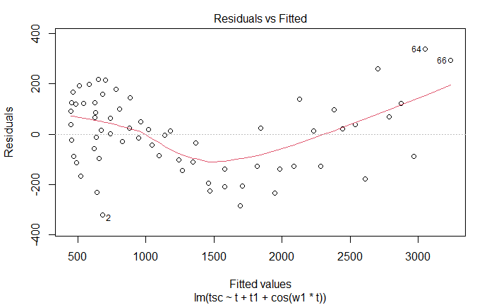

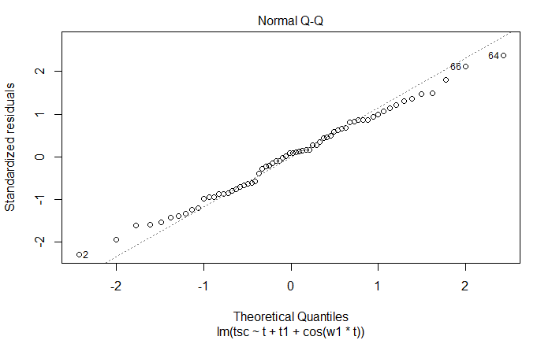

```r
plot(model1,which=1:2)
```

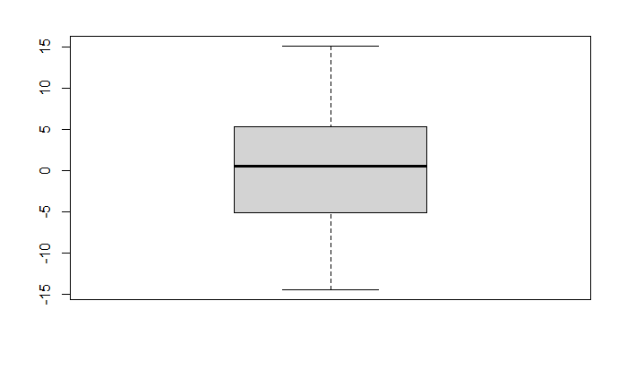

```r
sres1<-residuals(model1)/sqrt(494.8)
boxplot(sres1)
```

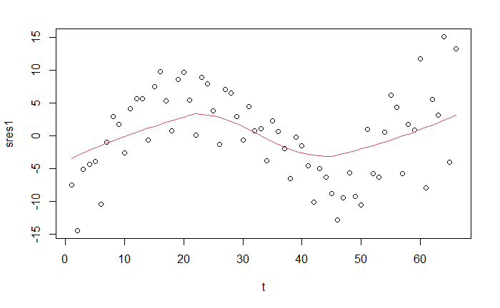

```r
plot(t,sres1)
lines(lowess(t,sres1),col=2)
```

```r
library(nortest)
ad.test(sres1)
```

```
    Anderson-Darling normality test

data:  sres1
A = 0.19833, p-value = 0.8827
```

```r
cvm.test(sres1)
```

```
    Cramer-von Mises normality test

data:  sres1
W = 0.033706, p-value = 0.7884
```

```r
lillie.test(sres1)
```

```
    Lilliefors (Kolmogorov-Smirnov) normality test

data:  sres1
D = 0.067717, p-value = 0.6377
```

```r
pearson.test(sres1)
```

```
    Pearson chi-square normality test

data:  sres1
P = 3.6667, p-value = 0.8859
```

```r
sf.test(sres1)
```

```
    Shapiro-Francia normality test

data:  sres1
W = 0.99403, p-value = 0.966
```

```r
model6<-tslm(tsc~trend+seasonality)
summary(model6)
plot(model1,which=1:2)
sres1<-residuals(model6)/sqrt(494.8)
boxplot(sres1)
plot(t,sres1)
lines(lowess(t,sres1),col=2)
library(nortest)
ad.test(sres1)
cvm.test(sres1)
lillie.test(sres1)
pearson.test(sres1)
sf.test(sres1)
```

2. Build an appropriate SARIMA model for the same, and iterprete the fitted model interms of its IRF, ACF, PACF and η2n’s. Do the residulas of this SARIMA model satisfy all the required assumptions? [8+8+4=20]